# Projet ADM Q5

RODRIGUES Camille-Astrid AMOUROUX Jan

2025-04-01

```r
habitat = read.table("../data/habitat.tsv", sep = "\t",
                     stringsAsFactors = T, header = T, na.strings = T)
habitat = habitat[,-2:-3] # on supprime le qualitatif (mauvais pour nous)

especes = read.table("../data/especes.tsv", sep = "\t",
                     stringsAsFactors = T, header = T, na.strings = T)

commu = read.table("../data/communautes.tsv", sep = "\t",
                   stringsAsFactors = T, header = T, na.strings = T)
```

======================= QUESTION 5 =======================

–> habitat : urbanisation –> espèces : protégée ou non ?

==> est-ce que les oiseaux protégés sont davantages présents dans les milieux urbains : protection intense par l’Homme, abondance de nourriture, absence de prédateurs, habitats cachés et sécuritaires…

## ANALYSE :

```r
vectCol = c("IdPE","agri","arbu","prai","foret","bati")
habitaEnv.subset = subset(habitat,select = vectCol)
```

## on vas chercher si ya une corrélation entre espèces protégé et l’espèce de volatile :

```r
# Récupération des noms des colonnes correspondant aux espèces (colonnes 2 à 17)
vectNom <- c("Myo", "Gem", "Meh", "Col", "Lon", "Cir", "Euh", "Orc", "Euj", "Cof", "Dep", "Mas", "Maf", "Saa", "Elm", "Tul")

# Création d'une liste vide pour stocker les sous-ensembles
listSubsets = list()
# Parcours de toutes les espèces
for (i in 1:length(vectNom)) {
  especesActu = vectNom[i]
  # Extraction des numéros de lieu (IdPE) où l'espèce a une présence (valeur 1)
  foosubset = commu$IdPE[commu[[especesActu]] == 1]
  listSubsets[[especesActu]] = foosubset
}

# /!\ va faire vla des lignes de variables :
```

on va faire comme a la Q4 mais avec plus de variable

```r
# Liste des noms d'habitat
habitat_names <- c("Myohabitat", "Gemhabitat", "Mehhabitat", "Colhabitat", "Lonhabitat",
                   "Cirhabitat", "Euhhabitat", "Orchabitat", "Eujhabitat", "Cofhabitat",
                   "Dephabitat", "Mashabitat", "Mafhabitat", "Saahabitat", "Elmhabitat", "Tulhabitat")

# liste des diminutif des noms
vectNom <- c("Myo", "Gem", "Meh", "Col", "Lon", "Cir", "Euh", "Orc", "Euj",
             "Cof", "Dep", "Mas", "Maf", "Saa", "Elm", "Tul")

# Liste des colonnes d'intérêt
vectCol <- c("agri", "arbu", "prai", "foret", "bati")

# Initialisation d'une liste pour stocker les données
meanList <- data.frame(matrix(ncol = length(vectCol) + 1, nrow = length(habitat_names)))

# Nommer les colonnes du dataframe
colnames(meanList) <- c("habitat", vectCol)

# Remplir le dataframe
for (i in seq_along(habitat_names)) {
  habitat <- habitat_names[i]
  habitat_data <- get(habitat)  # Récupération du dataframe

  # Calcul des moyennes pour chaque colonne d'intérêt
  mean_values <- sapply(vectCol, function(col) mean(habitat_data[[col]], na.rm = TRUE))

  # Stockage des résultats
  meanList[i, ] <- c(habitat, mean_values)
}

# Convertir la colonne 'habitat' en facteur ou caractère
meanList$habitat <- as.character(vectNom)

# Affichage du résultat
meanList = data.frame(meanList)

# Conversion des colonnes en numérique car bozo est char
meanList[,-1] <- lapply(meanList[,-1], as.numeric)
```

faire les dataframes

ACM entre les moyennes et les espèces :

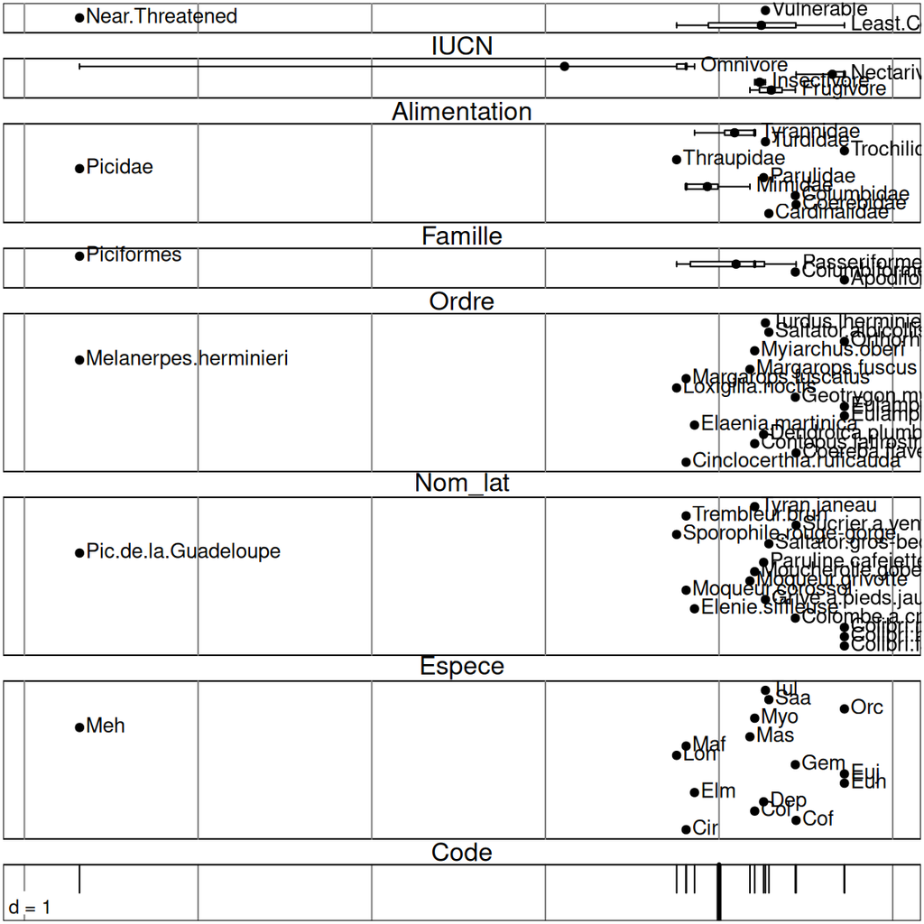

```r
ACM_Espèces = dudi.acm(especes[,-6],
                       scannf = FALSE, nf = 2)

boxplot(ACM_Espèces)
```

### AFD pour expliquer espèces par leur moyenne intra-espèces :

#### 1 faire l’ACP

```r
acp.meanhabi = dudi.pca(meanList[,-1],
         center = T, scale = T,
         scannf = FALSE, nf = 2)
```

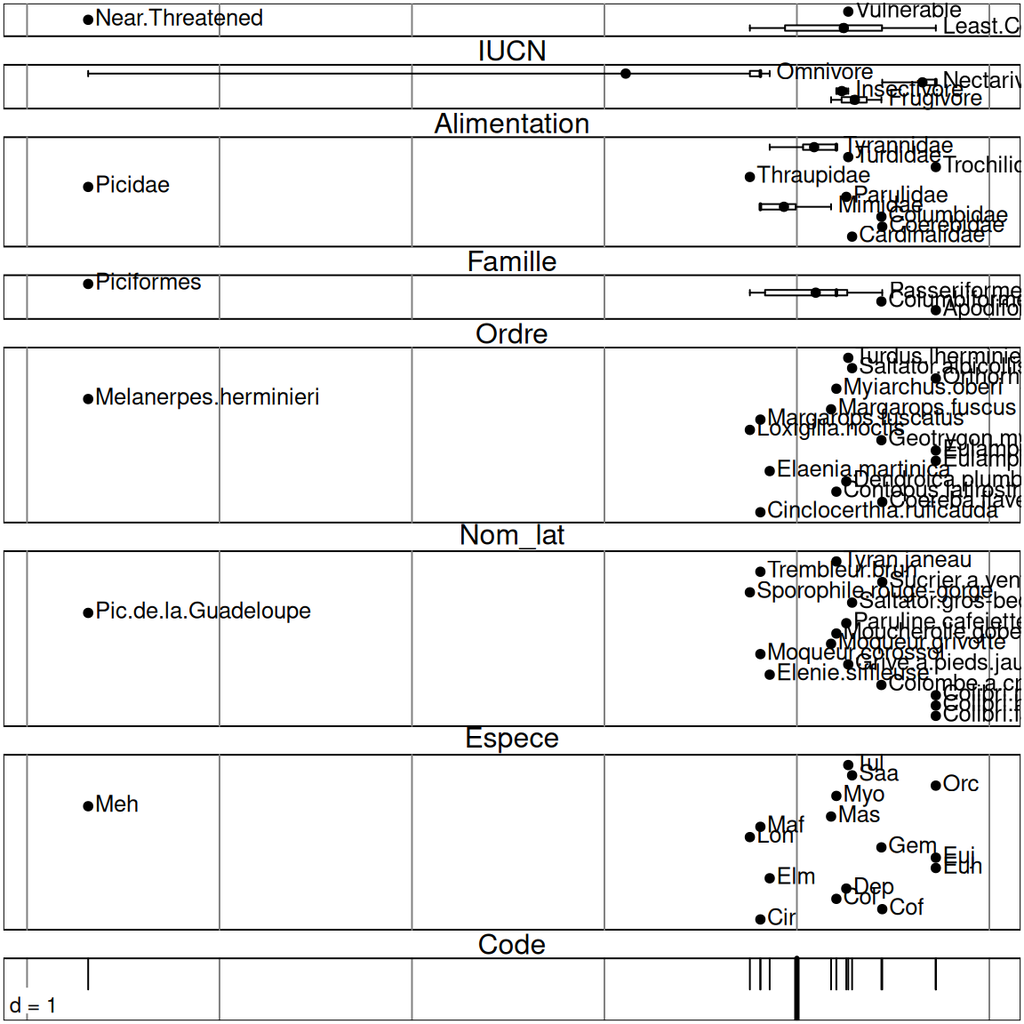

```r
acm.espèces = dudi.acm(as.data.frame(especes[-6]),
                       scannf = FALSE, nf = 2)
boxplot(acm.espèces)
```

```r
coinertie = coinertia(acm.espèces,acp.meanhabi,
                      scannf = FALSE, nf = 2); summary(coinertie)
```

```
## Coinertia analysis
##
## Class: coinertia dudi
## Call: coinertia(dudiX = acm.espèces, dudiY = acp.meanhabi, scannf = FALSE,
##     nf = 2)
##
## Total inertia: 2.857
##
## Eigenvalues:
##       Ax1       Ax2       Ax3       Ax4       Ax5
## 2.2849117 0.5220622 0.0381169 0.0118412 0.0003562
##
## Projected inertia (%):
##      Ax1      Ax2      Ax3      Ax4      Ax5
## 79.96784 18.27125  1.33403  0.41442  0.01247
##
## Cumulative projected inertia (%):
##     Ax1   Ax1:2   Ax1:3   Ax1:4   Ax1:5
##   79.97   98.24   99.57   99.99  100.00
##
## Eigenvalues decomposition:
##         eig     covar       sdX      sdY      corr
## 1 2.2849117 1.5115925 0.7922154 1.977465 0.9649009
## 2 0.5220622 0.7225387 0.7384785 1.006445 0.9721502
##
## Inertia & coinertia X (acm.espèces):
##      inertia      max     ratio
## 1  0.6276052 0.891648 0.7038711
## 12 1.1729557 1.729395 0.6782461
##
## Inertia & coinertia Y (acp.meanhabi):
##     inertia      max     ratio
## 1  3.910367 3.919180 0.9977513
## 12 4.923298 4.923885 0.9998808
##
## RV:
##  0.2988435
```

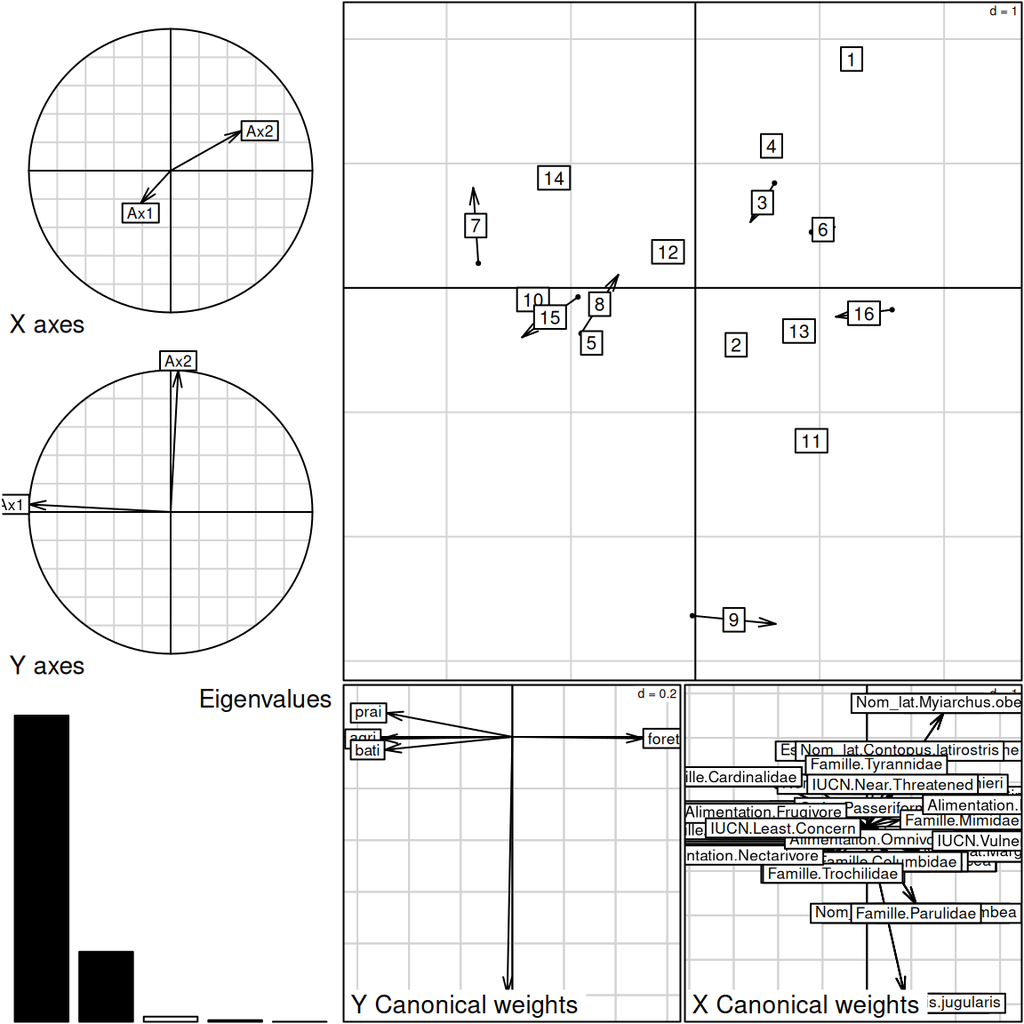

```r
plot(coinertie)
```

on arrive a séparer les espèces en fonctions decès variables environementales

[figure not shown]

```r
s.corcircle(coinertie$li)
```

les oiseaux protégés sont davantages présents dans les milieux urbains

–> protection intense par l’Homme, abondance de nourriture, absence de prédateurs, habitats cachés et sécuritaires…

OU

les oiseaux protégés sont très peu présents dans les milieux urbains –> prédaction par les chats domestiques, accidents avec les véhicules, pollution, peu d’alimentation naturelle, peu d’habitats naturels…